Skip to main content

# Do hormonal contraceptives differ in their effect?

Study B — three methods, 93 people, genes and microbiome

Author

Group B1–B5

> **What this deck is.** One presentation answering the three Study B questions — do the three methods differ in community composition, does the ring differ from the two systemic methods in host gene expression, and does community type explain the genes better than the method does. The full workings live in the workshop documents — `01-qc.html` (QC), `02-ring-vs-systemic.html` and `03-three-arms-review.html` (Question 2), `05-q1-three-arms-composition.html` (Question 1) and `06-q3-community-vs-method.html` (Question 3); this deck recomputes the headline numbers from the data so every slide can be traced. Because PowerPoint wants small numbers of things, each slide carries only the headline figure plus the sample sizes it is based on.

# Study B in one slide

## Who, what, how many

- **93 participants**, one vaginal swab each, **one visit** — no time course.
- Each person used one of three hormonal contraceptives **they chose themselves** (this is not a randomised trial):

| Method | Samples |
| --- | --- |
| Pill | 28 |
| Injectable | 39 |
| Vaginal ring | 26 |

- Two sequencing tables for the same 93 samples, features in rows: **species** (220 species × 93 samples) and **host genes** (14,226 genes × 93 samples), plus 15 cytokines.
- Question for the week: **do the methods differ in their effect?** We answer it three ways — on the microbiome, on the genes, and by asking whether “community type” explains the genes better than the method does.

## Before any result: what the arms might differ in *besides* the method

**No randomisation. People chose their method.** So any difference between arms could be the method, or something else that tracks the choice.

We checked the baseline variables (`01-qc.html`):

| Baseline variable | Different across arms? |
| --- | --- |
| Bacterial vaginosis | no (Fisher p = 0.63) |
| Any STI | no |
| Nugent score | no (p = 0.65) |
| Sequencing batch | no — every arm in both batches |
| **Vaginal pH** | **yes (Kruskal–Wallis p = 0.02)** |

- **The one real imbalance: vaginal pH.** Median 4.55 in the pill arm vs 5.0 in ring and injectable; the ring arm has no sample below pH 4.4.
- pH tracks both hormones and the vaginal microbiome, so it may be a *confounder* (distorting a method comparison) or on the *causal path* (part of the method’s effect). We show the unadjusted answer and note where pH changes it (Question 3 of `03-three-arms-review.html`).
- Everything we present is an **association in a self-chosen comparison**, not a trial effect.

## Power: who is compared with whom

Every comparison in this deck, with the samples it is built on:

| Comparison | n | Note |
| --- | --- | --- |
| All three arms | 93 | 28 pill / 39 injectable / 26 ring |
| ring vs pooled systemic | 26 vs 67 | the pooled control is **58 % injectable** |
| ring vs pill | 26 vs 28 | most even ring comparison |
| ring vs injectable | 26 vs 39 | most powerful ring comparison |
| pill vs injectable | 28 vs 39 | the pooling check |
| community type (2 groups) | 93 | 48 lactobacillus / 45 anaerobe |

- The ring arm is the smallest, so **ring comparisons have the least power**; a bigger arm finds more “significant” genes for the same true effect.
- With 26–39 per group, only **large gene-expression differences** reach FDR < 0.05; small shifts land in the “suggestive” pile.

# Question 1 — do the three methods differ in community composition?

## Q1: the microbiome map, three arms (n = 93)

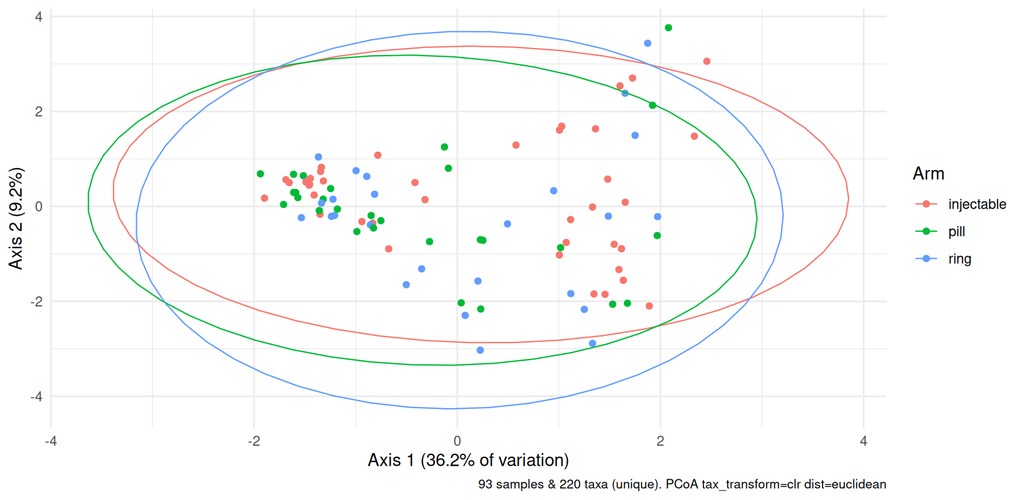

Species-table PCoA (CLR + Euclidean) coloured by arm.

```r
ps_sp <- as_counts(dataset = "group_b", table = "microbiome", data = d)
sd <- as(sample_data(ps_sp), "data.frame")
sd$arm <- md$arm[match(sd$sample_id, md$sample_id)]
sample_data(ps_sp) <- sample_data(sd)

ord_sp <- ps_sp |>
  tax_transform("clr", zero_replace = "halfmin") |>
  dist_calc("euclidean") |>
  ord_calc("PCoA")

eig <- attr(ord_sp, "ord")$CA$eig
sh  <- round(100 * eig / sum(eig), 1)

ord_plot(ord_sp, axes = 1:2, color = "arm") +
  stat_ellipse(aes(colour = arm), type = "norm", linewidth = 0.4) +
  labs(x = sprintf("Axis 1 (%s%% of variation)", sh[1]),
       y = sprintf("Axis 2 (%s%%)", sh[2]), colour = "Arm")
```

```r
dm_sp <- attr(ord_sp, "dist")
meta_sp <- data.frame(sample_data(ps_sp))[rownames(as.matrix(dm_sp)), ]
meta_sp$arm <- factor(meta_sp$arm, levels = c("ring", "pill", "injectable"))
set.seed(1)
# Same model as 05-q1-three-arms-composition.html: batch in, margin test.
q1_main <- adonis2(dm_sp ~ arm + rnaseq_batch, data = meta_sp,
                   permutations = 9999, by = "margin")
q1_r2 <- round(100 * q1_main$R2[1], 1)
q1_p  <- round(q1_main$`Pr(>F)`[1], 3)

pair_sp <- function(a, b) {
  keep <- meta_sp$arm %in% c(a, b)
  out  <- adonis2(as.dist(as.matrix(dm_sp)[keep, keep]) ~ arm,
                  data = droplevels(meta_sp[keep, ]), permutations = 9999)
  tibble(comparison = paste(a, "vs", b),
         n = sum(keep),
         `share of variation (%)` = round(100 * out$R2[1], 1),
         `p (raw)` = out$`Pr(>F)`[1])
}
q1_pairs <- bind_rows(pair_sp("ring", "pill"),
                      pair_sp("ring", "injectable"),
                      pair_sp("pill", "injectable")) |>
  mutate(`p (adjusted, BH)` = p.adjust(`p (raw)`, "BH"))

knitr::kable(
  tibble(comparison = "all three arms", n = nrow(md),
         `share of variation (%)` = round(100 * q1_main$R2[1], 1),
         `p (raw)` = q1_main$`Pr(>F)`[1]),
  caption = "PERMANOVA on species (CLR + Euclidean, adjusted for batch, 9,999 permutations)"
)
```

PERMANOVA on species (CLR + Euclidean, adjusted for batch, 9,999 permutations)

| comparison | n | share of variation (%) | p (raw) |
| --- | --- | --- | --- |
| all three arms | 93 | 2.8 | 0.1748 |

## Q1: the three methods do **not** carve the microbiome into three

```r
knitr::kable(q1_pairs,
  caption = "Pairwise PERMANOVA on species (9,999 permutations)")
```

Pairwise PERMANOVA on species (9,999 permutations)

| comparison | n | share of variation (%) | p (raw) | p (adjusted, BH) |
| --- | --- | --- | --- | --- |
| ring vs pill | 54 | 1.7 | 0.4579 | 0.4579 |
| ring vs injectable | 65 | 1.7 | 0.3079 | 0.4579 |
| pill vs injectable | 67 | 2.7 | 0.0834 | 0.2502 |

- **Answer: no clear three-way difference.** The main test puts 2.8 % of the species-level variation on the method (p = 0.175, 93 samples) — not significant.
- No pairwise comparison survives adjustment either. If the ring really reshaped the community differently from the systemic methods, we cannot see it here at this sample size.
- What *does* structure this map is **community type** (lactobacillus vs anaerobe, axis 1 holds 36 % — `01-qc.html`). That is the split Question 3 follows up.
- No individual species stands out either: **DESeq2 on raw species counts** gives hit counts at chance level in every comparison (`05-q1-three-arms-composition.html`).
- **Sanity check:** rerun `q1-permanova` with a different `set.seed` — the R² stays the same and the p-value should stay near 0.175.

# Question 2 — the ring is local, the others are systemic: do the genes differ?

## Q2: first ordinate the genes, all three arms (n = 93)

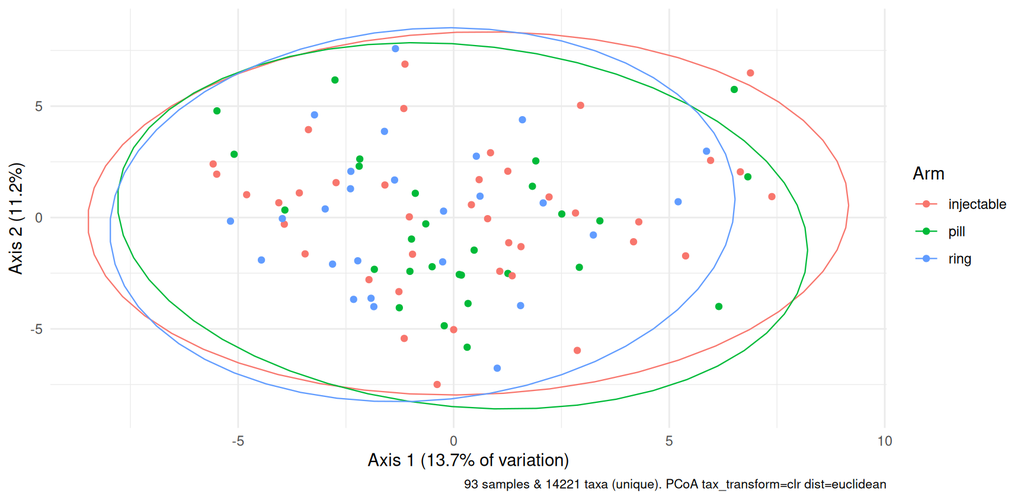

Gene-table PCoA (CLR + Euclidean, genes filtered at >=10 reads in >=10 samples) coloured by arm.

```r
ps_genes <- as_counts(dataset = "group_b", table = "rnaseq",
                      min_count = 10, min_samples = 10, data = d)
sdg <- as(sample_data(ps_genes), "data.frame")
idx <- match(sdg$sample_id, md$sample_id)
sdg$arm       <- md$arm[idx]
sdg$arm_group <- md$arm_group[idx]
sdg$community <- md$community[idx]
sample_data(ps_genes) <- sample_data(sdg)

ord_g <- ps_genes |>
  tax_transform("clr", zero_replace = "halfmin") |>
  dist_calc("euclidean") |>
  ord_calc("PCoA")

eig_g <- attr(ord_g, "ord")$CA$eig
sh_g  <- round(100 * eig_g / sum(eig_g), 1)

ord_plot(ord_g, axes = 1:2, color = "arm") +
  stat_ellipse(aes(colour = arm), type = "norm", linewidth = 0.4) +
  labs(x = sprintf("Axis 1 (%s%% of variation)", sh_g[1]),
       y = sprintf("Axis 2 (%s%%)", sh_g[2]), colour = "Arm")
```

```r
dm_g <- attr(ord_g, "dist")
meta_g <- data.frame(sample_data(ps_genes))[rownames(as.matrix(dm_g)), ]
meta_g$arm       <- factor(meta_g$arm,       levels = c("ring", "pill", "injectable"))
meta_g$arm_group <- factor(meta_g$arm_group, levels = c("systemic", "ring"))
set.seed(1)
q2_three <- adonis2(dm_g ~ arm + rnaseq_batch, data = meta_g,
                    permutations = 9999, by = "margin")
q2_pooled <- adonis2(dm_g ~ arm_group, data = meta_g, permutations = 9999)
disp_g <- permutest(betadisper(dm_g, meta_g$arm), permutations = 9999)
q2_arm_r2   <- round(100 * q2_three$R2[1], 1)   # row 1 = arm (margin test)
q2_arm_p    <- round(q2_three$`Pr(>F)`[1], 3)
q2_pool_r2  <- round(100 * q2_pooled$R2[1], 1)
q2_pool_p   <- round(q2_pooled$`Pr(>F)`[1], 3)
q2_disp_p   <- round(disp_g$tab$`Pr(>F)`[1], 2)
```

The arms overlap heavily on the map. The formal tests (9,999 permutations, 93 samples):

| Test | Share of variation | p |
| --- | --- | --- |
| arm (adjusted for batch) | 2.7 % | 0.101 |
| ring vs pooled systemic | 1.7 % | 0.041 |
| spread check (betadisper) | — | 0.66 |

- The pooled test’s p sits **on the 0.05 line** (reruns with other seeds gave 0.03–0.055) — call it *suggestive*, not established.
- The spread check says one arm is not just more scattered, which would fake a PERMANOVA difference.

## Q2: DESeq2 — ring vs pooled systemic (n = 26 vs 67)

```r
genes_f <- ge[rowSums(ge >= 10) >= 10, ]   # raw counts into DESeq2, always
rownames(md) <- md$sample_id

dds <- DESeq(DESeqDataSetFromMatrix(genes_f, md, design = ~ rnaseq_batch + arm_group),
             quiet = TRUE)
res <- results(dds, contrast = c("arm_group", "ring", "systemic"))
res_df <- as.data.frame(res) |>
  rownames_to_column("ensembl_gene_id") |>
  left_join(d$gene_info |> select(ensembl_gene_id, symbol),
            by = "ensembl_gene_id") |>
  mutate(symbol = coalesce(symbol, ensembl_gene_id),
         padj   = replace_na(padj, 1))
sig <- res_df |> filter(padj < 0.05)
```

- **165 genes at FDR < 0.05** (88 up in ring, 77 down) out of 14221 tested. Smallest FDR 2.6e-09.
- Dropping the blood-contaminated sample `B093` leaves **152 of 165 hits standing (92 %)** — the list does not hinge on one sample (`02-ring-vs-systemic.html`).
- Caveat from `03-three-arms-review.html`: the raw-p hit lists are about twice what chance alone gives, and several top hits are keratins and mucus genes — the signal may partly be **cell mix** (how much surface tissue each swab caught), not the ring.

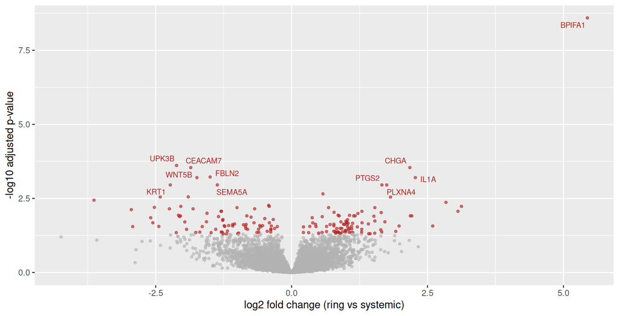

Volcano plot, ring vs systemic. Red: FDR < 0.05; labels: 10 smallest FDR.

```r
res_df |>
  mutate(hit  = padj < 0.05,
         label = if_else(rank(padj) <= 10, symbol, NA_character_)) |>
  ggplot(aes(log2FoldChange, -log10(padj), colour = hit)) +
  geom_point(size = 1, alpha = 0.6, show.legend = FALSE) +
  scale_colour_manual(values = c("grey70", "firebrick")) +
  geom_text_repel(aes(label = label), size = 2.8, max.overlaps = 20,
                  show.legend = FALSE) +
  labs(x = "log2 fold change (ring vs systemic)",
       y = "-log10 adjusted p-value")
```

## Is pooling pill + injectable fair? (n = 28 vs 39)

```r
knitr::kable(
  tribble(
    ~evidence, ~result,
    "pill vs injectable, DESeq2 genes at FDR < 0.05", "11 (chance would give ~5–7)",
    "pill vs injectable, raw p < 0.05", "738 vs ~711 expected by chance",
    "pill vs injectable, PERMANOVA (genes)", "1.4 %, p = 0.54",
    "ring LFC vs pill vs ring LFC vs injectable (all genes)", "r = 0.71, same direction",
  ),
  caption = "Evidence that the two systemic methods behave alike (from 03-three-arms-review.html)"
)
```

Evidence that the two systemic methods behave alike (from 03-three-arms-review.html)

| evidence | result |
| --- | --- |
| pill vs injectable, DESeq2 genes at FDR < 0.05 | 11 (chance would give ~5–7) |
| pill vs injectable, raw p < 0.05 | 738 vs ~711 expected by chance |
| pill vs injectable, PERMANOVA (genes) | 1.4 %, p = 0.54 |
| ring LFC vs pill vs ring LFC vs injectable (all genes) | r = 0.71, same direction |

- **Why it is fair:** the two systemic arms are near-indistinguishable in the genes — 11 hits where chance predicts about 7, PERMANOVA p = 0.54, and the ring’s log2 fold changes point the **same way against both** (r = 0.71).
- **Two caveats:** the pooled control is 58 % injectable, so “systemic” leans that way; and adjusting for the pH imbalance changes the ring-vs-pill list from 97 to 191 genes, so the pooled contrast is not the only defensible reading.
- Alternative we did not choose: keep the three arms separate (`03-three-arms-review.html` does exactly that as a check).

## Q2 verdict

- The gene *profile* differs only subtly between ring and the systemic methods: PERMANOVA 1.7 % (p ≈ 0.04, borderline), three-arm test p = 0.10.
- DESeq2 finds **165 genes at FDR < 0.05 (n = 26 vs 67)** — mostly small shifts, possibly partly cell-mix rather than a true ring effect.
- The effect, if real, is **modest** — no dramatic reprogramming of vaginal tissue. Follow-up: cytokines, cell-mix markers, and an independent cohort before calling it.

# Question 3 — group by community type, then test the genes

## Q3: two community types, one map (n = 93)

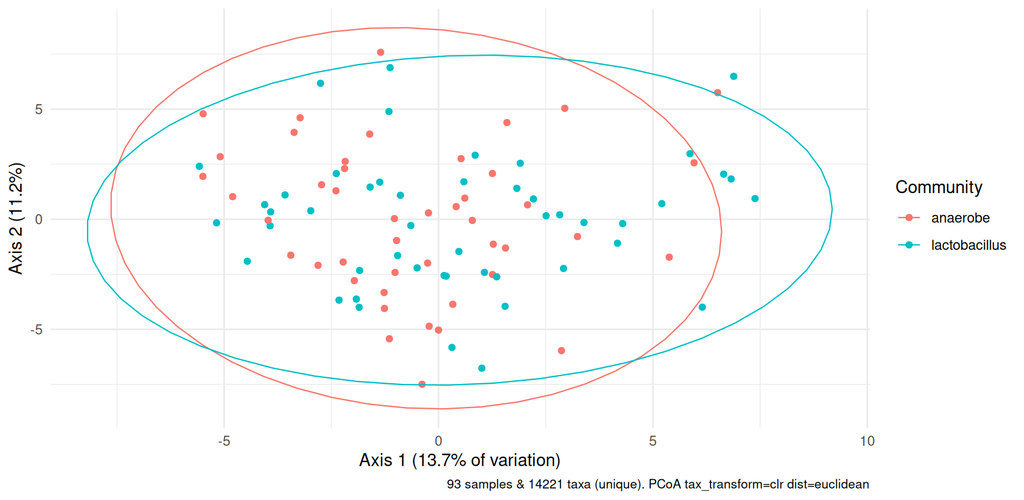

Gene-table PCoA (same distances as Q2) coloured by community type.

```r
ord_plot(ord_g, axes = 1:2, color = "community") +
  stat_ellipse(aes(colour = community), type = "norm", linewidth = 0.4) +
  labs(x = sprintf("Axis 1 (%s%% of variation)", sh_g[1]),
       y = sprintf("Axis 2 (%s%%)", sh_g[2]), colour = "Community")
```

```r
set.seed(1)
q3 <- adonis2(dm_g ~ community + arm_group, data = meta_g,
              permutations = 9999, by = "margin")
q3_comm_r2 <- round(100 * q3$R2[1], 1)   # row 1 = community (margin test)
q3_comm_p  <- round(q3$`Pr(>F)`[1], 4)
```

Community type was assigned from the **species** table (Lactobacillus ≥ 50 % of species reads) and is tested on the **gene** table — the group is never defined from the table it is tested on.

## Q3: does community type explain the genes better than the method?

```r
knitr::kable(
  tibble(term = c("community type", "method (ring vs systemic)"),
         n = c(93, 93),
         `share of variation (%)` = round(100 * q3$R2[1:2], 1),
         p = round(q3$`Pr(>F)`[1:2], 4)),
  caption = "PERMANOVA on genes: community vs method, each adjusted for the other (9,999 permutations)"
)
```

PERMANOVA on genes: community vs method, each adjusted for the other (9,999 permutations)

| term | n | share of variation (%) | p |
| --- | --- | --- | --- |
| community type | 93 | 1.4 | 0.1165 |
| method (ring vs systemic) | 93 | 1.6 | 0.0532 |

```r
dds_c <- DESeq(DESeqDataSetFromMatrix(genes_f, md, design = ~ rnaseq_batch + community),
               quiet = TRUE)
res_c <- results(dds_c, contrast = c("community", "anaerobe", "lactobacillus"))
sig_c <- sum(res_c$padj < 0.05, na.rm = TRUE)
```

```r
knitr::kable(
  tribble(
    ~grouping, ~`PERMANOVA share (%)`, ~p, ~`DESeq2 genes at FDR < 0.05`,
    "community type (48 vs 45)",  q3_comm_r2, q3_comm_p, sig_c,
    "method, ring vs systemic (26 vs 67)",
      q2_pool_r2, q2_pool_p, nrow(sig),
  ),
  caption = "The two groupings head to head on the same gene table"
)
```

The two groupings head to head on the same gene table

| grouping | PERMANOVA share (%) | p | DESeq2 genes at FDR < 0.05 |
| --- | --- | --- | --- |
| community type (48 vs 45) | 1.4 | 0.1165 | 312 |
| method, ring vs systemic (26 vs 67) | 1.7 | 0.0410 | 165 |

- **Answer: about a tie on the overall map, community ahead gene by gene.** On total variation the two groupings explain about the same small share (1.4 % vs 1.7 %), and neither marginal p-value is convincing. But gene by gene community type is the stronger signal: **312 genes at FDR < 0.05** vs 165 for ring vs systemic.
- The two groupings are **not the same thing in disguise**: community composition is balanced across the arms (chi-squared p = 0.50), so this is a fair head-to-head, not a confounded one.
- Why the mismatch between one map and many genes? A modest, consistent shift spread over many genes can pass the per-gene FDR while moving the overall profile only slightly.
- Practical upshot for the group project: **adjust for community type** (or stratify by it) before interpreting gene differences between methods — and expect the method signal, if real, to be the smaller of the two.
- One more reason to adjust: **vaginal pH tracks community type far more strongly than it tracks the method** (p ≈ 1e-07 vs 0.02, `06-q3-community-vs-method.html`), and the two gene lists barely overlap (27 shared genes) — they are different signals, not one signal seen twice.
- Full workings: `06-q3-community-vs-method.html`.

# Wrapping up

## The three answers in three lines

1. **Community composition:** the three methods do **not** differ detectably (PERMANOVA 2.8 %, p = 0.175, n = 93). The strong structure is community type, not method.
2. **Ring vs systemic genes:** a **small, suggestive** difference — 1.7 % of variation (p = 0.041) and 165 genes at FDR < 0.05 (n = 26 vs 67), with cell-mix and pH caveats. Pooling the pill with the injectable is supported by the data (11 hits, p = 0.54, r = 0.71).
3. **Community type vs method:** about a tie on the overall gene map (1.4 % vs 1.7 % of variation, both weak p-values), but community type finds many more individual genes (312 vs 165). The groupings are independent (community is balanced across arms, p = 0.50) — report both, and adjust for community when reading method effects.

**Standing caveat for all three:** people chose their method, the arms differ in vaginal pH, and the ring arm is the smallest (n = 26) — treat every p-value here as a lead, not a verdict.

## Choices made

- **Answered the workshop’s three questions in this order** — composition, ring-vs-systemic, community-vs-method — one headline figure each; the alternative was to show every plot from the five analysis documents, which would bury the answers.
- **Community type defined from the species table and tested on the gene table** (Lactobacillus ≥ 50 % of species reads, the notebook 02 rule); a stricter cut-off (60 %) or a third intermediate group is the alternative.
- **Species ordination/PERMANOVA on the unfiltered species table** with CLR + Euclidean (half-min replacement), matching `01-qc.html`; filtering rare species first is the alternative.
- **Gene ordination and DESeq2 on genes with ≥ 10 reads in ≥ 10 samples**, matching `02-ring-vs-systemic.qmd`; a stricter filter loses power, a laxer one wastes tests.
- **Raw counts into DESeq2** (it normalises itself); CPM or logged values would be wrong.
- **Reported both the three-arm and the pooled ring-vs-systemic PERMANOVA** — the pooled one is the workshop’s question but sits on the p = 0.05 line; showing only it would overstate the evidence.
- **Quoted the pairwise DESeq2 and pH-sensitivity numbers from `03-three-arms-review.html` rather than recomputing them** here; rerunning every fit in the deck is the alternative.
- **Kept the deck as a summary layer over the five analysis documents** (`01` QC, `02`+`03` Question 2, `05` Question 1, `06` Question 3) rather than re-deriving every sensitivity check on a slide.
- **Used 9,999 permutations and `by = "margin"`** for all PERMANOVA in this deck, following the review document’s correction of the sequential test.
- **Did not adjust the main results for pH** (it may be on the causal path); where pH matters we say so explicitly — the fully adjusted model is the alternative.